# Statistics for Soil Survey Part 1 - Final Project

Tyler Staggs

May 2, 2018

## Statistics for Soil Survey Part 1: Final Project

All libraries loaded for the project.

```r
library(soilDB)
library(aqp)
library(plyr)
library(ggplot2)
library(sp)
library(rgdal)
library(maps)
```

### Project Area

The project area selected is MLRA 114B. This MLRA has two, unconnected sections and this project includes both sections, one in Illinois and one in Indiana.

Map of MLRA 114B

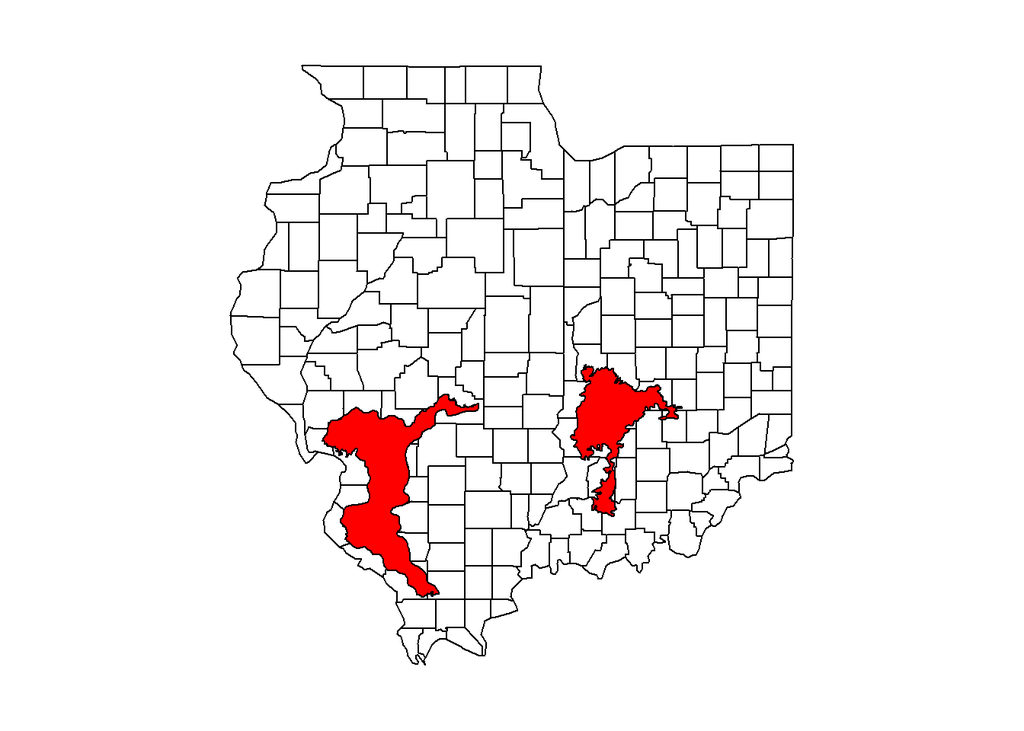

```r
par(mar=c(0,0,0,0))
map('county', c('illinois', 'indiana'))
MLRAboundary<-readOGR(dsn = 'H:/Desktop/Ecological_Sites/ESD_Projects/MLRA_114B_Project/GIS', layer = 'MLRA_114B_WGS84')
convertcoords<-spTransform(MLRAboundary, CRS('+proj=longlat + datum=WGS84'))
cbind(utm=coordinates(MLRAboundary), gcs=coordinates(convertcoords))
MLRAboudary<-SpatialPolygons2map(convertcoords)
map(MLRAboundary, fill = TRUE, col = 2, add=TRUE)
```

```r
dev.off()
```

### Objectives

My workload is centered around ecological site development. The objectives of this investigation is to use the functions within R to accomplish the following tasks:

1. Sort the soils into groups based on select types of parent material.
2. Determine the soils in a group that have calcium carbonate percentage of 10% or greater
3. Determine the depth at which the calcium carbonate percentage is 10% or greater

### Results

To begin the investigation, the first step was to load all the component data for MLRA 114B into NASIS. The fetchNASIS function was used to import the data into R.

```r
project1<-fetchNASIS(from = 'components')
```

I then indexed the data using the grep function to select the soils with ‘lacustrine’ in the parent material kind. I will state now, that this step will need further refinement as the text within the rows for parent material often contain multiple types of listed parent material. The result of this step is a SoilProfileCollection of all the soils with ‘lacustrine’ listed in the pmkind row of the compenent data.

```r
lac_idx<-grep('lacustrine', project1$pmkind )
project_lacustrine<-project1[lac_idx,]
```

A function was created that would select all of the soils from a target dataset that had a calcium carbonate (CaCO3) percentage greater than or equal ten percent in any and all horizons.

```r
findCACO3<-function(i){
h<-horizons(i)

idx<- which(h$caco3_r >= 10)

res<-h[idx, c('coiid', 'caco3_r', 'hzdept_r')]

return(res)
}
```

This function was then used on the indexed dataset resulting in a listing of all lacustrine soils in the data set that contained a horizon with 10% or more CaCO3.

```r
lacustrine_caco3 = findCACO3(project_lacustrine)
knitr::kable(lacustrine_caco3[1:10,])
```

[output not shown]

```r
lac_caco3_depth<-ddply(lacustrine_caco3, 'coiid', summarise,
                       depth_to_caco3_cm = min(hzdept_r),
                       caco3_class = cut(depth_to_caco3_cm, breaks = c(0,30,60,250)))
knitr::kable(lac_caco3_depth[1:10,])
```

| coiid | depth_to_caco3_cm | caco3_class |
| --- | --- | --- |
| 236910 | 25 | (0,30] |
| 239548 | 99 | (60,250] |
| 239551 | 97 | (60,250] |
| 241265 | 107 | (60,250] |
| 241268 | 107 | (60,250] |
| 241283 | 18 | (0,30] |
| 241284 | 25 | (0,30] |
| 241296 | 86 | (60,250] |
| 241339 | 79 | (60,250] |
| 241626 | 91 | (60,250] |

A bar plot was created that showed the number of soils in each class. This list was short enough to be counted by hand, but this function would be usefull for larger datasets.

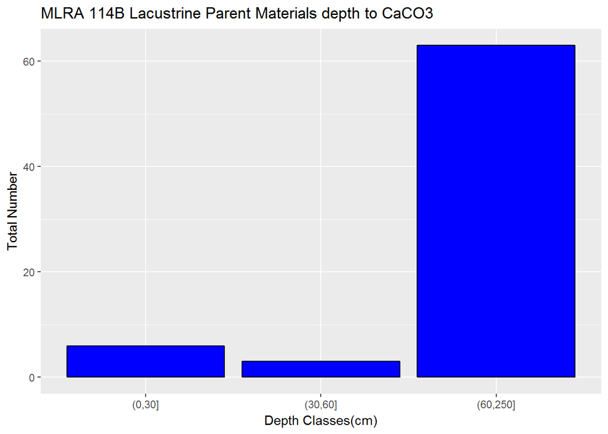

```r
par(mar=c(1,1,1,1))
ggplot(data = lac_caco3_depth, aes(x=caco3_class))+geom_bar(colour="black", fill="blue")+xlab("Depth Classes(cm)")+ylab("Total Number")+ggtitle("MLRA 114B Lacustrine Parent Materials depth to CaCO3")
```

```r
dev.off()
```

To get a better handle on the depth at which CaCO3 was occuring, as well as to test my R abilities, I plotted the depth of the minimum depth of CaCO3 on each soil plot. This involved indexing the SoilProfileCollection on the table created using the ‘coiid’ data as the selection criteria.

```r
idx <- which(site(project_lacustrine)$coiid %in% lac_caco3_depth$coiid)
proj_lac_caco3<-project_lacustrine[idx, ]

par(mar=c(0,0,2,1))
plot(proj_lac_caco3, print.id=FALSE)
```

```
## guessing horizon designations are stored in `hzname`
```

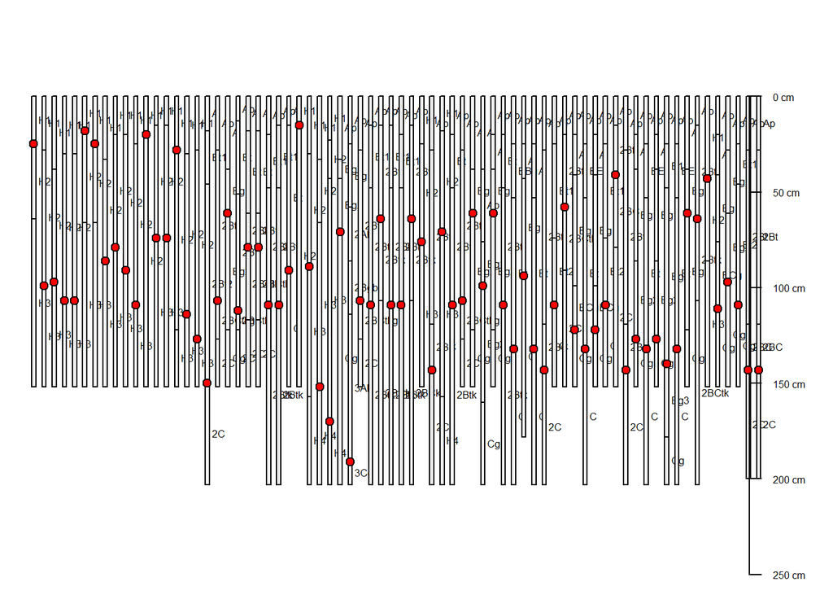

```r
points(x=1:length(proj_lac_caco3), y=lac_caco3_depth$depth_to_caco3_cm, pch=21, bg='red', col='black')
```

```r
dev.off()
```

```r
lac_site<-site(proj_lac_caco3)
lac_site<-lac_site[,c(1,3)]
lac_site<-merge(lac_caco3_depth,lac_site, by='coiid', sort = TRUE)
lac_site$caco3_class.y<-lac_site$caco3_class
colnames(lac_site)[colnames(lac_site)=='caco3_class.y']<-'Glacial Period'
lac_site$`Glacial Period`<-as.character(lac_site$`Glacial Period`)
lac_site$`Glacial Period`[lac_site$`Glacial Period`=="(30,60]"]<-"Illinoian"
lac_site$`Glacial Period`[lac_site$`Glacial Period`=="(60,250]"]<-"Wisconsin"
lac_site<-lac_site[!lac_site$`Glacial Period`=="(0,30]",]
lac_site<-lac_site[!duplicated(lac_site[,4]),]
knitr::kable(lac_site)
```

|  | coiid | depth_to_caco3_cm | caco3_class | compname | Glacial Period |
| --- | --- | --- | --- | --- | --- |
| 2 | 239548 | 99 | (60,250] | McGary | Wisconsin |
| 3 | 239551 | 97 | (60,250] | Montgomery | Wisconsin |
| 4 | 241265 | 107 | (60,250] | Henshaw | Wisconsin |
| 8 | 241296 | 86 | (60,250] | Patton | Wisconsin |
| 9 | 241339 | 79 | (60,250] | Zipp | Wisconsin |
| 10 | 241626 | 91 | (60,250] | Markland | Wisconsin |
| 18 | 244352 | 150 | (60,250] | Greybrook | Wisconsin |
| 21 | 244424 | 112 | (60,250] | Pottersville | Wisconsin |
| 24 | 244433 | 109 | (60,250] | Shircliff | Wisconsin |
| 26 | 244450 | 91 | (60,250] | Stubenville | Wisconsin |
| 28 | 265185 | 89 | (60,250] | Bartelso | Wisconsin |
| 29 | 265186 | 152 | (60,250] | Lakaskia | Wisconsin |
| 30 | 265210 | 170 | (60,250] | Wagner | Wisconsin |
| 31 | 284369 | 71 | (60,250] | Milford | Wisconsin |
| 32 | 285499 | 191 | (60,250] | Southwest | Wisconsin |
| 45 | 1181002 | 99 | (60,250] | Montgomery, overwash | Wisconsin |
| 48 | 1326186 | 132 | (60,250] | Reesville | Wisconsin |
| 63 | 1367984 | 140 | (60,250] | Zipp variant | Wisconsin |
| 67 | 2117666 | 43 | (30,60] | Hartsburg | Illinoian |

### Discussion

Reports have been created in NASIS that generate tables from which the majority of the soils information that is required for the early stages of ecological site develop. Much of the sorting and categorizing of this information/data is done through brute force and ‘hand’ sorted using a spreadsheet. The application of the functions and tools within R, once setup, make for a much more efficient way of sorting soils for the purposes of developing ecological sites. Likewise, the basic reports from NASIS do not always contain all of the information/data that can be pertinent to a given project. The information investigated as part of this project is a pertinent example. It was suggested to use the depth of CaCO3 to seperate soils. That information is not on the report, nor is it consistently reported in the OSDs. Being able to replicate a process that can be tailored to an issue or a project is very valuable. My lack of ability to write reports in NASIS would have required an investigation into multiple soil component child tables that can be done much faster in R. With the changing of a few parameters in the coding, I can now perform this same investigation on other sets of data.

Many of the ecological site projects that I have completed are quite similar in nature. Criteria used for sorting soils and establishing differences been ecological sites are often parent material, drainage, and surface color. An expansion of the process as used in this project would allow for a much quicker process in doing that in the future or in retrospect if field data warrants that things are not as hypothesized.

As noted above, the project as conducted is not without flaws. I bit more work would allow some of the sorting, subsetting, or indexing criteria to be a bit more specific. This is not a R problem, but an ability/time problem with the operator, and by extension an issue with the data as entered. Further refinement would allow for a more conise and targeted investigation of the soils. In summary, I think the methods taught in this class and as investigated through this project will greatly enchance the speed and efficiency in which ecological sites are developed. Use of R as a tool seems to have gained acceptance and compiled a history of success with soil surveys and I hope to extend that to ecological site projects throughout our region.

### Example B

To further test the method developed for this project, the process as described above was replicated on other soils within MLRA 114B.

```r
project1<-fetchNASIS(from = 'components')


out_idx<-grep('outwash', project1$pmkind )
project_outwash<-project1[out_idx,]

findCACO3<-function(i){
  h<-horizons(i)

  idx<- which(h$caco3_r >= 10)

  res<-h[idx, c('coiid', 'caco3_r', 'hzdept_r')]

  return(res)
}

outwash_caco3 = findCACO3(project_outwash)
knitr::kable(outwash_caco3[1:10,])
```

|  | coiid | caco3_r | hzdept_r |
| --- | --- | --- | --- |
| 2176 | 236868 | 10 | 152 |
| 9034 | 236911 | 25 | 191 |
| 9039 | 236912 | 25 | 191 |
| 9043 | 236913 | 23 | 191 |
| 9047 | 236914 | 23 | 191 |
| 9051 | 236915 | 23 | 191 |
| 9088 | 236933 | 15 | 198 |
| 9092 | 236934 | 15 | 198 |
| 9096 | 236935 | 15 | 198 |
| 9111 | 236941 | 40 | 97 |

```r
out_caco3_depth<-ddply(outwash_caco3, 'coiid', summarise,
                       depth_to_caco3_cm = min(hzdept_r),
                       caco3_class = cut(depth_to_caco3_cm, breaks = c(0,30,60,250)))
knitr::kable(out_caco3_depth[1:10,])
```

| coiid | depth_to_caco3_cm | caco3_class |
| --- | --- | --- |
| 236868 | 152 | (60,250] |
| 236911 | 191 | (60,250] |
| 236912 | 191 | (60,250] |
| 236913 | 191 | (60,250] |
| 236914 | 191 | (60,250] |
| 236915 | 191 | (60,250] |
| 236933 | 198 | (60,250] |
| 236934 | 198 | (60,250] |
| 236935 | 198 | (60,250] |
| 236941 | 97 | (60,250] |

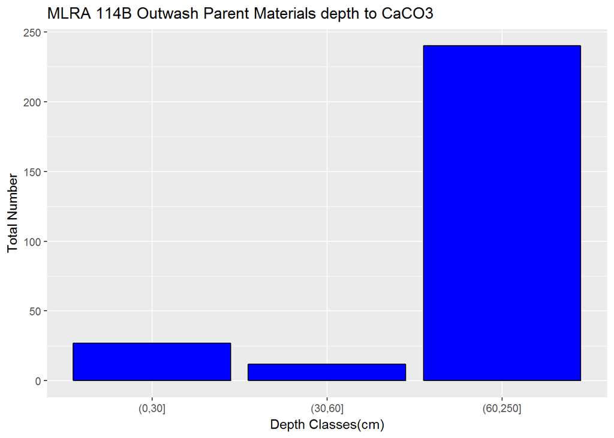

```r
par(mar=c(1,1,1,1))
ggplot(data = out_caco3_depth, aes(x=caco3_class))+geom_bar(colour="black", fill="blue")+xlab("Depth Classes(cm)")+ylab("Total Number")+ggtitle("MLRA 114B Outwash Parent Materials depth to CaCO3")
```

```r
dev.off()
```

null device 1

```r
idx <- which(site(project_outwash)$coiid %in% out_caco3_depth$coiid)
proj_out_caco3<-project_outwash[idx, ]

par(mar=c(0,0,2,1))
plot(proj_out_caco3, print.id=FALSE)
points(x=1:length(proj_out_caco3), y=out_caco3_depth$depth_to_caco3_cm, pch=21, bg='red', col='black')
dev.off()
```

[output not shown]

null device 1

```r
out_site<-site(proj_out_caco3)
out_site<-out_site[,c(1,3)]
out_site<-merge(out_caco3_depth,out_site, by='coiid', sort = TRUE)
out_site$caco3_class.y<-out_site$caco3_class
colnames(out_site)[colnames(out_site)=='caco3_class.y']<-'Glacial Period'
out_site$`Glacial Period`<-as.character(out_site$`Glacial Period`)
out_site$`Glacial Period`[out_site$`Glacial Period`=="(30,60]"]<-"Illinoian"
out_site$`Glacial Period`[out_site$`Glacial Period`=="(60,250]"]<-"Wisconsin"
out_site<-out_site[!out_site$`Glacial Period`=="(0,30]",]
out_site<-out_site[!duplicated(out_site[,4]),]
knitr::kable(out_site)
```

|  | coiid | depth_to_caco3_cm | caco3_class | compname | Glacial Period |
| --- | --- | --- | --- | --- | --- |
| 1 | 236868 | 152 | (60,250] | Lyles | Wisconsin |
| 2 | 236911 | 191 | (60,250] | Camden | Wisconsin |
| 7 | 236933 | 198 | (60,250] | Elston | Wisconsin |
| 10 | 236941 | 97 | (60,250] | Fox | Wisconsin |
| 18 | 236977 | 165 | (60,250] | Ockley | Wisconsin |
| 23 | 237010 | 183 | (60,250] | Sleeth | Wisconsin |
| 25 | 237016 | 107 | (60,250] | Warsaw | Wisconsin |
| 26 | 237021 | 140 | (60,250] | Westland | Wisconsin |
| 32 | 237059 | 71 | (60,250] | Martinsville | Wisconsin |
| 35 | 237076 | 91 | (60,250] | Rensselaer | Wisconsin |
| 43 | 238174 | 127 | (60,250] | Proctor | Wisconsin |
| 64 | 239637 | 122 | (60,250] | Whitaker | Wisconsin |
| 91 | 242686 | 84 | (60,250] | Mahalasville | Wisconsin |
| 96 | 243004 | 135 | (60,250] | Drummer | Wisconsin |
| 106 | 244469 | 109 | (60,250] | Wea | Wisconsin |
| 129 | 259345 | 117 | (60,250] | Pike | Wisconsin |
| 134 | 260551 | 119 | (60,250] | Elburn | Wisconsin |
| 148 | 280991 | 117 | (60,250] | Mahalaland | Wisconsin |
| 155 | 285317 | 104 | (60,250] | Digby | Wisconsin |
| 156 | 285318 | 114 | (60,250] | Haney | Wisconsin |
| 157 | 285319 | 40 | (30,60] | Casco | Illinoian |
| 158 | 285460 | 89 | (60,250] | Wawaka | Wisconsin |
| 161 | 286386 | 112 | (60,250] | Millbrook | Wisconsin |
| 164 | 867691 | 183 | (60,250] | Waupecan | Wisconsin |
| 182 | 1091579 | 76 | (60,250] | Tuscola | Wisconsin |
| 189 | 1517176 | 152 | (60,250] | Plano | Wisconsin |
| 217 | 1698136 | 127 | (60,250] | Thorp | Wisconsin |
| 226 | 2009822 | 147 | (60,250] | Kendall | Wisconsin |
| 227 | 2009824 | 112 | (60,250] | Brooklyn | Wisconsin |
| 257 | 2375216 | 76 | (60,250] | Aquic Hapludalfs | Wisconsin |
| 258 | 2375272 | 163 | (60,250] | poorly drained aqualfs | Wisconsin |
| 267 | 2454843 | 137 | (60,250] | Thackery | Wisconsin |

In less than 5 minutes time of using the find and replace functions in R editor I was able to replicate the process for a new parent material grouping for the MLRA. More generic file/object names would cut down on the number of replacements one would need to make. The more elaborate naming structure was used as I wanted to see item by item that the code was working and the results.